# Lab 1: ARIMA models

## Use ACF and PACF

Use the ACF and PACF plots to explore the time series. What did you learn? Also try decomposition.

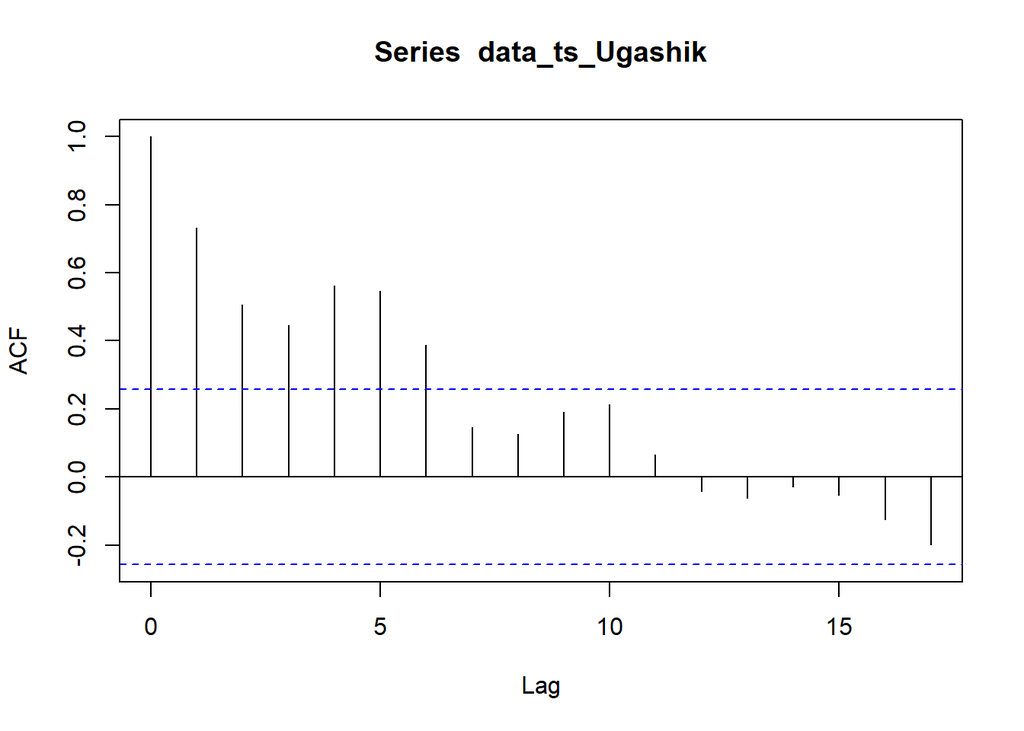

```r
data_ts_Ugashik <- ts(subdata$lntotal[subdata$system == "Ugashik"],
                      start=subdata$ret_yr[subdata$system == "Ugashik"][1])
data_ts_Wood <- ts(subdata$lntotal[subdata$system == "Wood"],
                      start=subdata$ret_yr[subdata$system == "Wood"][1])
train_Ugashik <- window(data_ts_Ugashik, 1963, 2005)
test_Ugashik <- window(data_ts_Ugashik, 2006, 2020)

train_Wood <- window(data_ts_Wood, 1963, 2005)
test_Wood <- window(data_ts_Wood, 2006, 2020)

acf(data_ts_Ugashik)
```

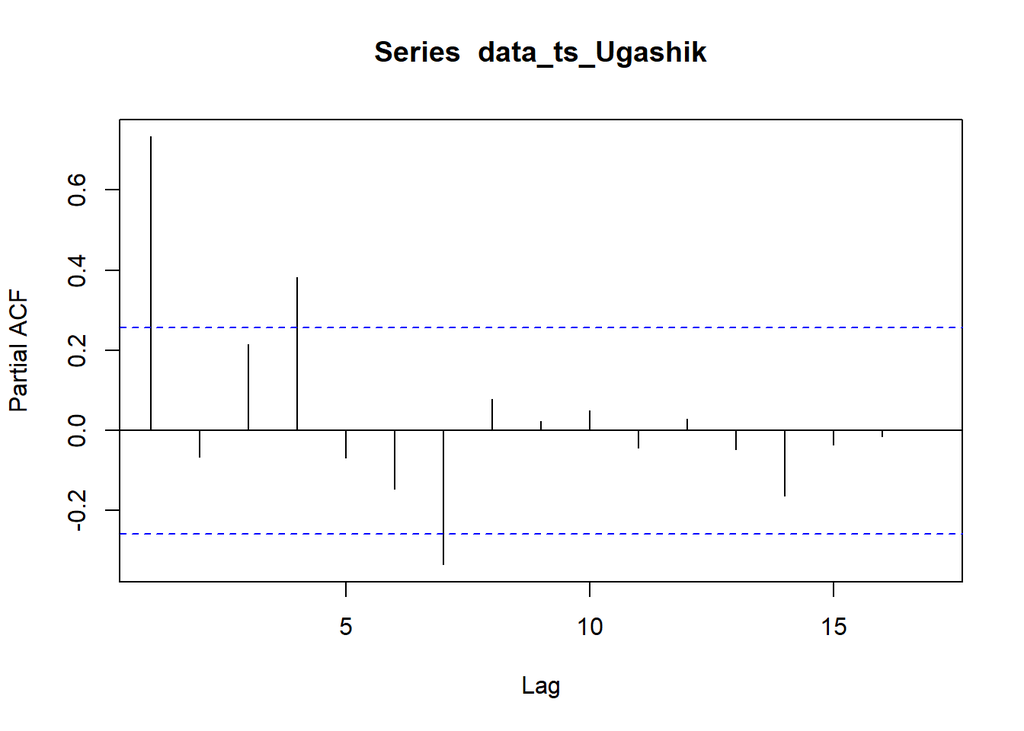

```r
pacf(data_ts_Ugashik)
```

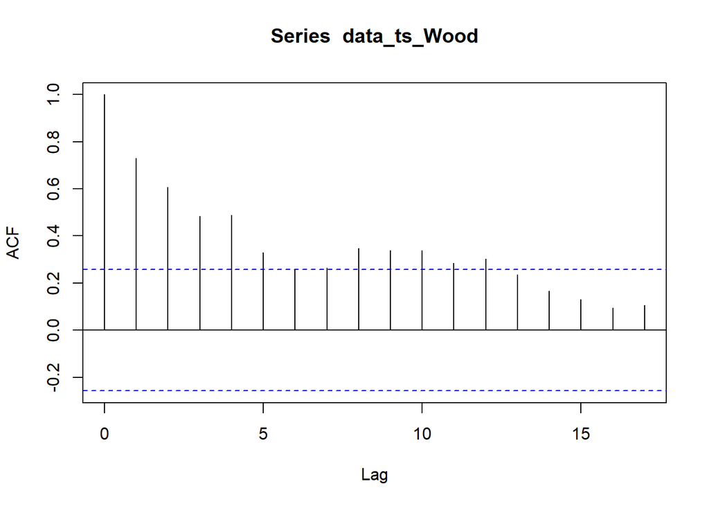

```r
acf(data_ts_Wood)
```

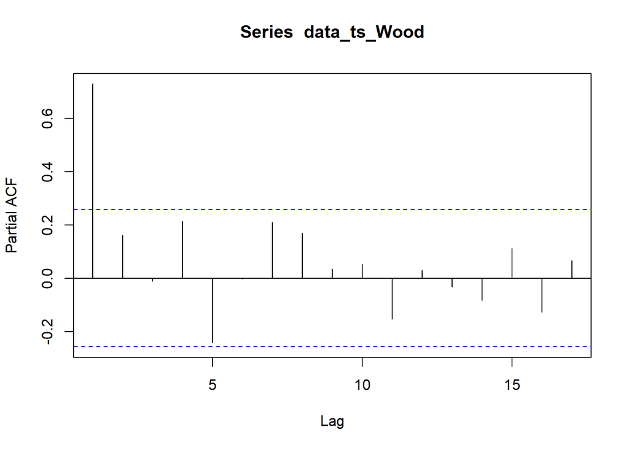

```r
pacf(data_ts_Wood)
```

The acf plots for both rivers are both slowly decaying and the pacf plots for both rivers show significants at various lags. In the Ugashik river lags 1, 4 and 7 are significant whereas in the Wood river, only lag 1 is significant. There might be AR1 structure in the ata from both rivers with some potentially higher order AR terms in Ugashik.

## Test for stationarity

Run tests and discuss any stationarity issues and how these were addressed.

```r
library(forecast)
mod_Ugashik <- auto.arima(data_ts_Ugashik)
mod_Ugashik
```

```
## Series: data_ts_Ugashik
## ARIMA(0,1,0)
##
## sigma^2 = 0.7894:  log likelihood = -74.14
## AIC=150.28   AICc=150.35   BIC=152.32
```

```r
mod_Wood <- auto.arima(data_ts_Wood)
mod_Wood
```

```
## Series: data_ts_Wood
## ARIMA(1,1,1)
##
## Coefficients:
##          ar1      ma1
##       0.3969  -0.8184
## s.e.  0.1755   0.1041
##
## sigma^2 = 0.218:  log likelihood = -36.7
## AIC=79.4   AICc=79.85   BIC=85.53
```

auto.arima suggests that ARIMA(0,1,0) fits Ugashik river data the best and ARIMA(1,1,1) fits the Wood river data the best.

```r
library(tseries)
adf.test(data_ts_Ugashik, k = 0)
```

```
##
##  Augmented Dickey-Fuller Test
##
## data:  data_ts_Ugashik
## Dickey-Fuller = -3.5726, Lag order = 0, p-value = 0.0433
## alternative hypothesis: stationary
```

```r
kpss.test(data_ts_Ugashik, null =c("Level"))
```

```
##
##  KPSS Test for Level Stationarity
##
## data:  data_ts_Ugashik
## KPSS Level = 0.79781, Truncation lag parameter = 3, p-value = 0.01
```

```r
##Tests give different results
## Ugashik data is probably NON stationary


adf.test(data_ts_Wood, k = 0)
```

```
##
##  Augmented Dickey-Fuller Test
##
## data:  data_ts_Wood
## Dickey-Fuller = -5.0089, Lag order = 0, p-value = 0.01
## alternative hypothesis: stationary
```

```r
kpss.test(data_ts_Wood, null =c("Trend"))
```

```
##
##  KPSS Test for Trend Stationarity
##
## data:  data_ts_Wood
## KPSS Trend = 0.040572, Truncation lag parameter = 3, p-value = 0.1
```

```r
#note that this gives different results depending on what null is

#wood is stationary around trend
```

Wood river data is probably stationary around a trend, but tests give differnet results for Ugashik data. Ugashik data is probably non stationary.

```r
ndiffs(data_ts_Ugashik, test='kpss')
```

```
## [1] 1
```

```r
ndiffs(data_ts_Ugashik, test='adf')
```

```
## [1] 1
```

```r
ndiffs(data_ts_Wood, test='kpss')
```

```
## [1] 1
```

```r
ndiffs(data_ts_Wood, test='adf')
```

```
## [1] 1
```

## Differencing the data

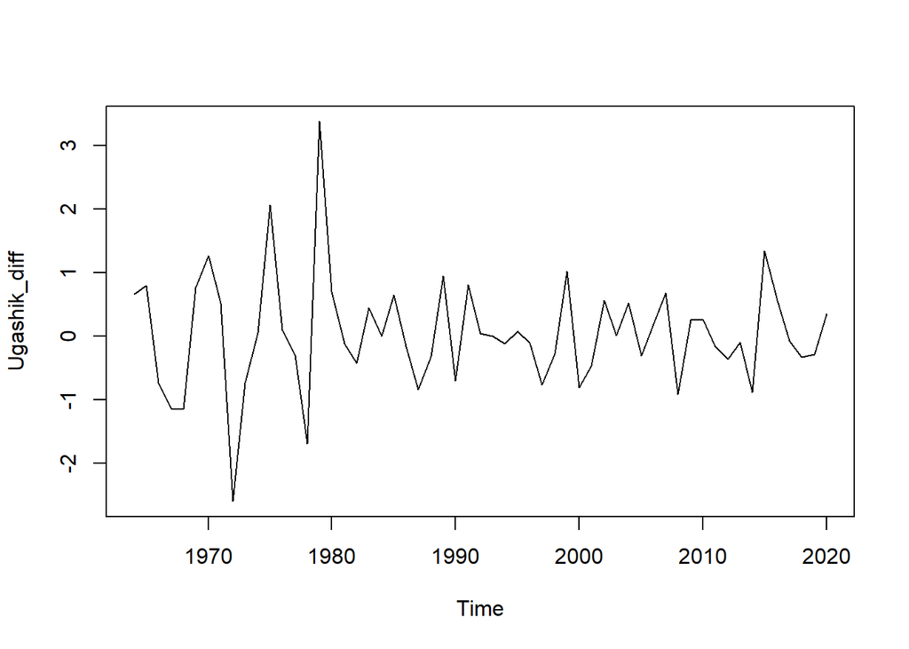

```r
Ugashik_diff <- diff(data_ts_Ugashik)
Wood_diff <- diff(data_ts_Wood)

plot.ts(Ugashik_diff)
```

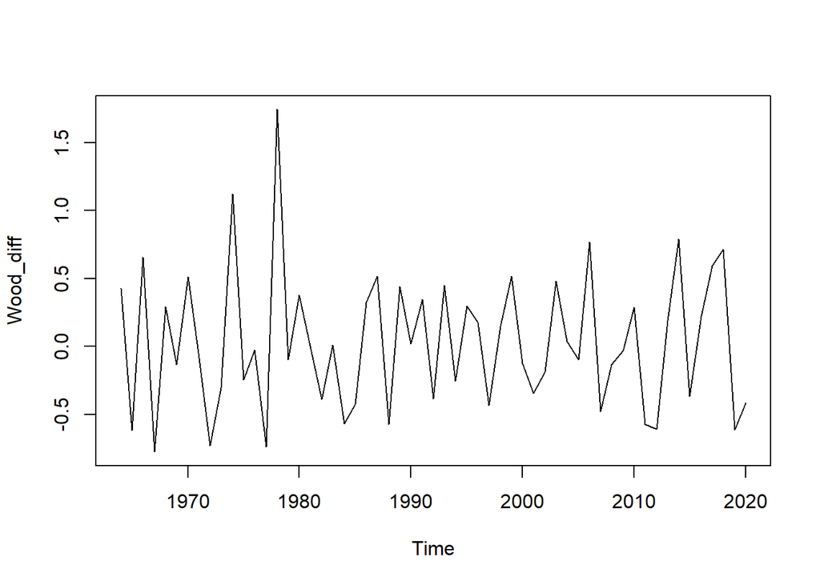

```r
plot.ts(Wood_diff)
```

This looks pretty stationary.

## Stationarity on differenced data

```r
adf.test(Ugashik_diff, k = 0)
```

```
##
##  Augmented Dickey-Fuller Test
##
## data:  Ugashik_diff
## Dickey-Fuller = -7.7412, Lag order = 0, p-value = 0.01
## alternative hypothesis: stationary
```

```r
kpss.test(Ugashik_diff, null =c("Level"))
```

```
##
##  KPSS Test for Level Stationarity
##
## data:  Ugashik_diff
## KPSS Level = 0.056441, Truncation lag parameter = 3, p-value = 0.1
```

These results say Ugashik data is probably stationary.

```r
adf.test(Wood_diff, k = 0)
```

```
##
##  Augmented Dickey-Fuller Test
##
## data:  Wood_diff
## Dickey-Fuller = -9.9733, Lag order = 0, p-value = 0.01
## alternative hypothesis: stationary
```

```r
kpss.test(Wood_diff, null =c("Level"))
```

```
##
##  KPSS Test for Level Stationarity
##
## data:  Wood_diff
## KPSS Level = 0.037388, Truncation lag parameter = 3, p-value = 0.1
```

These results say that Wood river data is also probably stationary.